# Venice is drowning - ARIMA model

# Overview

Come prima parte del progetto, abbiamo provveduto ad implementare due modelli ARIMA basati ognuno sull’utilizzo di alcuni regressori come contributo ulteriore, oltre alle componenti autoregressive e media mobile, alla previsione del livello di marea nella laguna di Venezia.

Il primo di questi modelli si basa sull’utilizzo di alcuni variabili meteorologiche, ovvero pioggia (mm), direzione del vento (gradi) e velocità del vento (m/s), unite al tracciamento del ciclo lunare (ricavato grazie all’API *PyEphem*) come regressori.

Il secondo modello invece utilizza come regressori una serie di armoniche descrittive dei cicli di marea ricavate grazie al pacchetto *oce*.

# Preparazione dei dati

Come primo passo importiamo i dati necessari

```r
data <- read.csv("../data/output/df_final2010-2018.csv", header = T)
lunar_motion <- read.csv("../moon_distance/moon_distances.csv", header = T)
data$l_motion <- 1/lunar_motion$dists.Km.^2
```

a questo punto possiamo limitare i dati al nostro intervallo di interesse ovvero a partire dal 24/06/2018 00:00:00 al 31/12/2018 alle 23:00:00.

```r
data[data$datetime=="2018-06-24 00:00:00",]
```

```
                 datetime level rain vel_wind dir_wind     l_motion
74305 2018-06-24 00:00:00    10    0      1.2    112.5 6.433774e-12
```

```r
trn <- data[74305:(nrow(data)-336),] # train sono 6 mesi meno 1 settimana
tst <- data[(nrow(data)-335):nrow(data),] # val 1 settimana + test 1 settimana
```

dopo una serie di ispezioni riguardanti frequenze all’interno della serie storica, stazionarietà in media (che viene confermata), stazionarietà in varianza (anche questa confermata) e normalità della serie (stabilendo quindi l’equivalenza tra stazionarietà debole e forte).

Continuiamo nella preparazione dei dati standardizzando i regressori

```r
xreg <- matrix(c(as.vector(scale(trn$rain)),
                 as.vector(scale(trn$vel_wind)),
                 as.vector(scale(trn$dir_wind)),
                 as.vector(scale(trn$l_motion))), ncol = 4)

col_names <- c("rain", "vel_wind", "dir_wind", "l_motion")
colnames(xreg) <- col_names

xreg_test <- matrix(c(as.vector(scale(tst$rain)),
                      as.vector(scale(tst$vel_wind)),
                      as.vector(scale(tst$dir_wind)),
                      as.vector(scale(tst$l_motion))), ncol = 4)

colnames(xreg_test) <- col_names

xreg <- rbind(xreg, xreg_test)

Hmisc::describe(xreg, digits = 2, tabular = F, title = "Regressors")
```

```
xreg

 4  Variables      4584  Observations
---------------------------------------------------------------------------
rain
       n  missing distinct     Info     Mean      Gmd      .05      .10
    4584        0       39    0.324   -8e-18     0.28    -0.14    -0.14
     .25      .50      .75      .90      .95
   -0.14    -0.14    -0.14    -0.13     0.21

lowest : -0.1435196 -0.1295799  0.2142686  0.5720568  0.9298450
highest: 15.2413730 16.6725258 17.0303140 19.8926196 20.2504078
---------------------------------------------------------------------------
vel_wind
       n  missing distinct     Info     Mean      Gmd      .05      .10
    4584        0      106    0.999  5.6e-17        1    -1.21    -1.12
     .25      .50      .75      .90      .95
   -0.68    -0.15     0.48     1.12     1.72

lowest : -1.567326 -1.526308 -1.478445 -1.389564 -1.349831
highest:  5.987577  6.076458  6.609745  6.965270  7.676320
---------------------------------------------------------------------------
dir_wind
       n  missing distinct     Info     Mean      Gmd      .05      .10
    4584        0       32     0.98 -2.2e-17      1.1    -0.90    -0.90
     .25      .50      .75      .90      .95
   -0.90    -0.47     0.62     1.31     2.37

lowest : -1.2339451 -1.0644416 -0.9034119 -0.8949381 -0.7254346
highest:  1.4982853  1.7166215  1.9349576  2.1532937  2.3716298
---------------------------------------------------------------------------
l_motion
       n  missing distinct     Info     Mean      Gmd      .05      .10
    4584        0     4574        1  3.6e-16      1.1    -1.32    -1.20
     .25      .50      .75      .90      .95
   -0.92    -0.14     0.86     1.41     1.66

lowest : -2.064069 -2.057880 -2.045931 -2.026666 -2.005534
highest:  2.279803  2.312341  2.317387  2.335461  2.337218
---------------------------------------------------------------------------
```

e concludiamo l’elaborazione dei dati visualizzando i plot di autocorrelazione e autocorrelazione parziale:

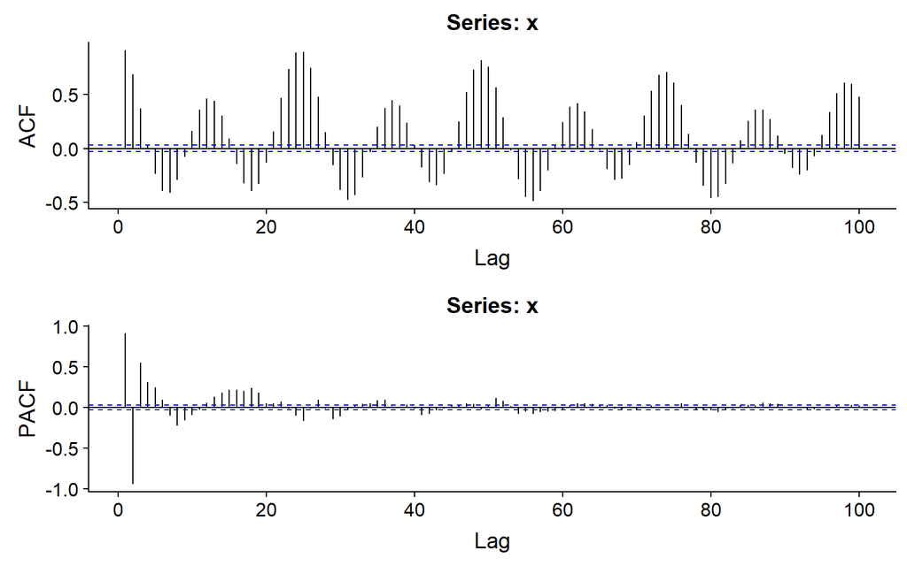

```r
acfpacf(trn$level, max.lag = 100)
```

# Modelli ARIMA

Come anticipato i modelli realizzati sono due, mentre uno utilizza come regressori variabili meteorologiche e ciclo lunare (assumendo quindi che per un modello in “produzione” sia possibile disporre di previsioni meteo piuttosto accurate e del tracciamento del ciclo lunare, questo, deterministico) l’altro si serve di alcune armoniche descrittive dei cicli di marea ottenute attraverso funzioni del tempo (per questa ragione, quindi, deterministiche anche queste e proiettabili per poter fare previsione).

## Variabili meteo e ciclo lunare

Il primo modello presentato è quello composto caratterizzato dall’utilizzo di variabili meteorologiche e ciclo lunare. Come si può vedere l’inserimento dei regressori sembra spiegare molto poco rispetto ai valori assunti dalla serie storica

```r
mod1_ar_baseline <- Arima(trn$level+0.1, xreg = xreg[1:4248,,drop=FALSE],
                 include.drift = T,
                 c(0,0,0), list(order = c(0,0,0), period = 24))

summary(mod1_ar_baseline)
```

```
Series: trn$level + 0.1
Regression with ARIMA(0,0,0) errors

Coefficients:
      intercept   drift     rain  vel_wind  dir_wind  l_motion
        26.1627  0.0048  -0.3826    6.1611    2.8208    1.6244
s.e.     0.7852  0.0003   0.3966    0.4110    0.4086    0.3932

sigma^2 estimated as 653.9:  log likelihood=-19794.46
AIC=39602.93   AICc=39602.95   BIC=39647.41

Training set error measures:
                       ME     RMSE      MAE       MPE     MAPE     MASE
Training set 1.198274e-13 25.55352 20.81305 -171.0167 352.6818 2.231978
                 ACF1
Training set 0.898117
```

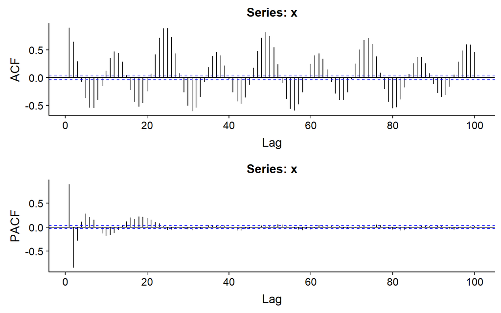

```r
acfpacf(mod1_ar_baseline$residuals, max.lag = 100)
```

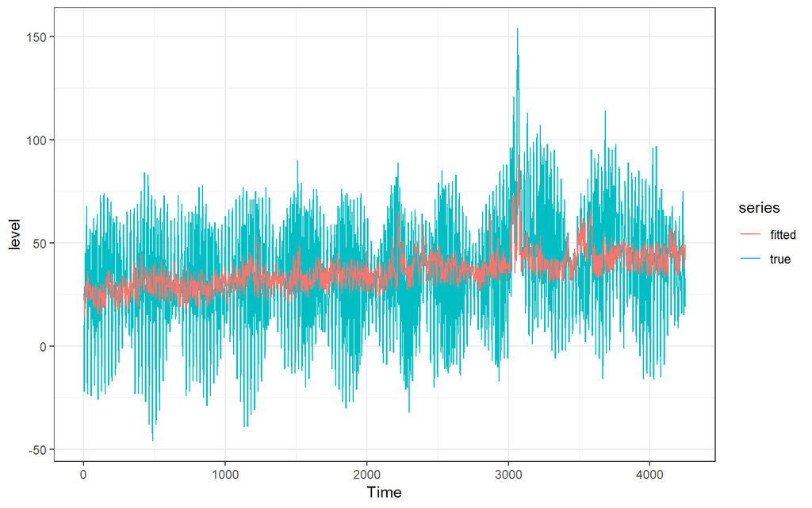

```r
autoplot(ts(trn$level), series = "true")+theme_bw()+labs(y = "level")+autolayer(ts(mod1_ar_baseline$fitted), series = "fitted")
```

A questo punto, seguendo i valori di AICc, MAPE e quelli di autocorrelazione e autocorrelazione parziale siamo giunti ad una forma finale per il modello che non risulta in una risoluzione definitiva ma che sembrerebbe il miglior modello ottenibile sotto queste condizioni.

```r
mod1_ar <- Arima(trn$level+0.1, xreg = xreg[1:4248,,drop=FALSE],
                 include.drift = F,
                 c(3,1,3), list(order = c(1,1,3), period = 24))

summary(mod1_ar)
```

```
Series: trn$level + 0.1
Regression with ARIMA(3,1,3)(1,1,3)[24] errors

Coefficients:
         ar1      ar2     ar3     ma1     ma2     ma3     sar1     sma1
      2.3166  -1.9916  0.5669  -1.663  0.8338  0.0671  -0.0354  -0.6371
s.e.  0.0317   0.0555  0.0317   0.036  0.0559  0.0297   0.1005   0.0989
         sma2     sma3    rain  vel_wind  dir_wind  l_motion
      -0.1601  -0.1165  0.0303    0.2998    0.0264   -4.1002
s.e.   0.0727   0.0246  0.0214    0.0606    0.0229    1.8711

sigma^2 estimated as 4.812:  log likelihood=-9324.97
AIC=18679.93   AICc=18680.05   BIC=18775.16

Training set error measures:
                        ME   RMSE      MAE       MPE     MAPE     MASE
Training set -0.0002587349 2.1836 1.628516 0.5592257 15.13516 0.174641
                    ACF1
Training set -0.00204861
```

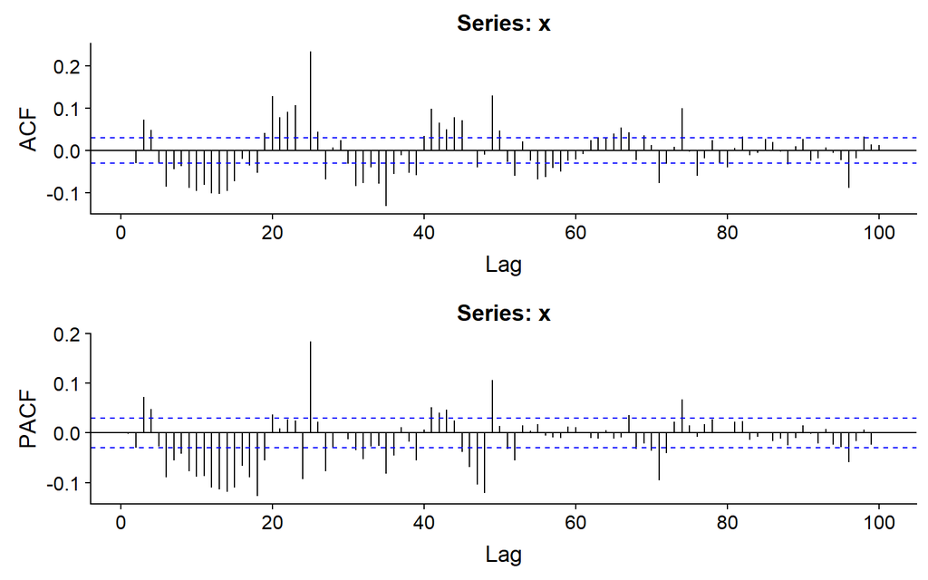

```r
acfpacf(mod1_ar$residuals, max.lag = 100)
```

come si vede dal grafico di autocorrelazione infatti quest’ultima non è stata completamente assorbita; tuttavia il test di Box-Ljung certifica che i residui risultino white noise almeno per quanto riguarda la prima ora di lag

```r
Box.test(mod1_ar$residuals, type="Ljung-Box")
```

```
    Box-Ljung test

data:  mod1_ar$residuals
X-squared = 0.017841, df = 1, p-value = 0.8937
```

anche i risultati di fitting insample sembrano migliorare parecchio

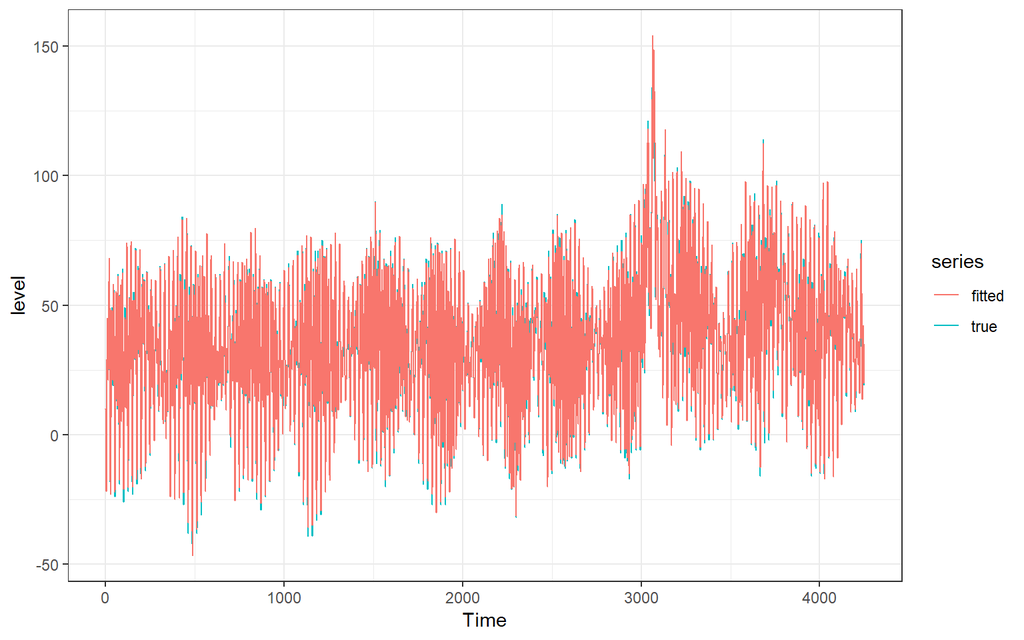

```r
autoplot(ts(trn$level), series = "true")+theme_bw()+labs(y = "level")+autolayer(ts(mod1_ar$fitted), series = "fitted")
```

più avanti verrano presentate le performances.

## Armoniche

Il primo modello, come mostrato, performa piuttosto bene ma è molto complesso dal punto di vista della magnitudine dei parametri. L’approccio presentato di seguito, invece, riesce ad ottenere performances anche migliori utilizzando come regressori 8 armoniche descrittive dei cicli di marea, rappresentanti ognuna una particolare grandezza influente sul livello delle onde, come per esempio il semi-ciclo lunare, quello solare e altro ancora.

Per ricavare queste armoniche ci serviamo del pacchetto *oce*

```r
data <- read.csv("../data/output/df_final2010-2018.csv", header = T)
lunar_motion <- read.csv("../moon_distance/moon_distances.csv", header = T)
data$l_motion <- 1/lunar_motion$dists.Km.^2
datsl <- as.sealevel(data$level/100)
constituents <- c('M2', 'S2', 'N2', 'K2', 'K1', 'O1', 'SA', 'P1')
preds <- sapply(constituents, function(x){

  mod <- tidem(t = datsl, constituent = x)
  pred <- predict(mod)
  pred - mean(pred)

})
predall <- rowSums(preds) + mean(datsl[['elevation']])
preds <- data.frame(time = datsl[['time']], preds, Estimated = predall)
data$M2 <- preds$M2
data$S2 <- preds$S2
data$N2 <- preds$N2
data$K2 <- preds$K2
data$K1 <- preds$K1
data$O1 <- preds$O1
data$SA <- preds$SA
data$P1 <- preds$P1

trn <- data[74305:(nrow(data)-336),]
tst <- data[(nrow(data)-335):nrow(data),]

col_names <- c("M2", "S2", "N2","K2", "K1", "O1", "SA", "P1")
xreg_arm <- matrix(c(trn$M2, trn$S2, trn$N2, trn$K2, trn$K1, trn$O1, trn$SA, trn$P1), ncol = 8)
xreg_test <- matrix(c(tst$M2, tst$S2, tst$N2, tst$K2, tst$K1, tst$O1, tst$SA, tst$P1), ncol = 8)
colnames(xreg_arm) <- col_names
colnames(xreg_test) <- col_names


xreg_arm <- rbind(xreg_arm, xreg_test)
```

```r
mod2_ar_baseline <- Arima((trn$level/100)+0.001, xreg = xreg_arm[1:4248,,drop=F],
                 include.drift = T,
                 c(0,0,0)
                 , list(order = c(0,0,0), period = 24))

summary(mod2_ar_baseline)
```

```
Series: (trn$level/100) + 0.001
Regression with ARIMA(0,0,0) errors

Coefficients:
      intercept  drift      M2      S2      N2      K2      K1      O1
         0.2623  1e-04  1.0127  1.0216  0.9743  1.0381  0.9717  1.0612
s.e.     0.0037  0e+00  0.0108  0.0193  0.0656  0.0785  0.0162  0.0586
           SA      P1
      -0.3201  0.8686
s.e.   0.1781  0.0492

sigma^2 estimated as 0.0145:  log likelihood=2969.65
AIC=-5917.3   AICc=-5917.24   BIC=-5847.41

Training set error measures:
                       ME      RMSE        MAE       MPE     MAPE
Training set 7.062977e-15 0.1202709 0.07874676 -19.75621 78.50905
                  MASE      ACF1
Training set 0.8444752 0.9707587
```

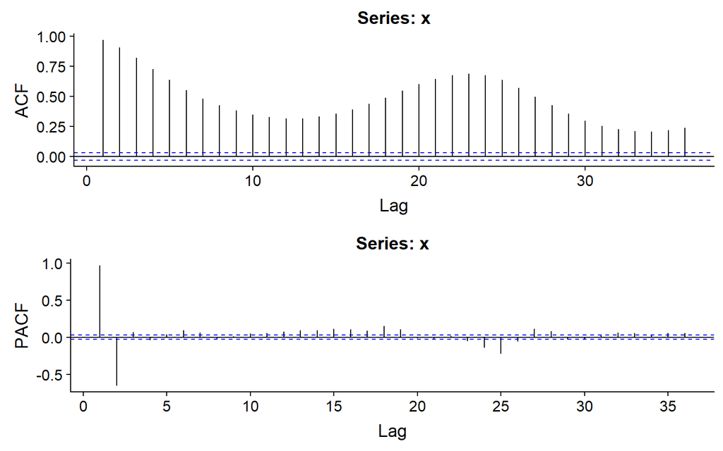

```r
acfpacf(mod2_ar_baseline$residuals)
```

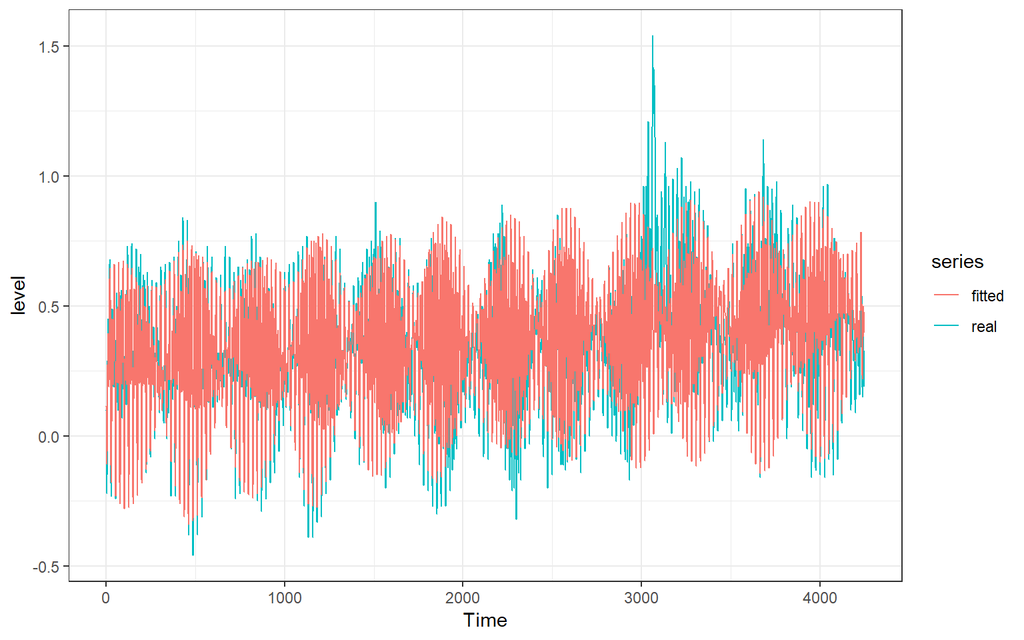

```r
autoplot(ts(trn$level/100), series = "real") +theme_bw()+labs(y="level")+ autolayer(mod2_ar_baseline$fitted, series = "fitted")
```

Come si vede il solo utilizzo delle armoniche permette di fittare molto bene la parte insample della serie. A questo punto seguendo il medesimo approccio utilizzato con il modello precedente provvediamo a raggiungere un modello finale.

```r
mod2_ar <- Arima((trn$level/100)+0.001, xreg = xreg_arm[1:4248,,drop=F],
                 include.drift = F,
                 c(3,0,2)
                 , list(order = c(1,0,0), period = 24))

summary(mod2_ar)
```

```
Series: (trn$level/100) + 0.001
Regression with ARIMA(3,0,2)(1,0,0)[24] errors

Coefficients:
         ar1      ar2      ar3     ma1      ma2    sar1  intercept      M2
      1.2718  -0.1645  -0.1690  0.3023  -0.0650  0.2952     0.3074  1.0138
s.e.  0.1688   0.2501   0.0919  0.1679   0.0291  0.0159     0.0142  0.0100
          S2      N2      K2      K1      O1      SA      P1
      1.0222  0.9708  1.0342  0.9707  1.0568  2.5058  0.8648
s.e.  0.0178  0.0588  0.0719  0.0369  0.1360  0.4839  0.1123

sigma^2 estimated as 0.0004271:  log likelihood=10456.12
AIC=-20880.23   AICc=-20880.11   BIC=-20778.57

Training set error measures:
                        ME       RMSE        MAE        MPE     MAPE
Training set -6.239502e-06 0.02062918 0.01530349 -0.3596771 14.80391
                  MASE          ACF1
Training set 0.1641137 -0.0005322583
```

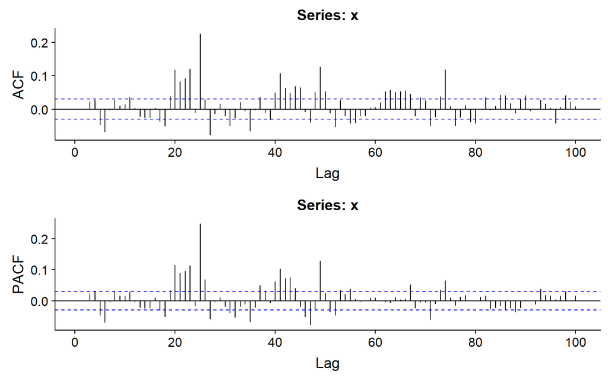

```r
acfpacf(mod2_ar$residuals, max.lag = 100)
```

```r
Box.test(mod2_ar$residuals, type="Ljung-Box")
```

```
    Box-Ljung test

data:  mod2_ar$residuals
X-squared = 0.0012043, df = 1, p-value = 0.9723
```

A questo punto non resta che confrontare i modelli sulla base delle performances raggiunte sul validation e sul test set.

# Risultati

Procediamo ad effettuare le valutazioni del modello: allo scopo di effettuare una valutazione più robusta abbiamo deciso di effettuare uno scoring di due tipi per entrambi i modelli, un primo basato sulla previsione one-shot, ovvero prevedere come già fatto tutto l’orizzonte del test set e verificare come è andata la previsione 1 ora in avanti, 24 ore in avanti (come somma delle previsioni da 1 a 24 ore in avanti) e 168 ore in avanti (come somma degli errori di previsione da 1 a 168 ore in avanti), il secondo metodo invece consiste nell’iterare di un passo per 168 volte ed effettuare i 3 tipi di previsione in modo da verificare le effettive performances medie indipendentemente dal punto di partenza della previsione.

Confrontiamo innanzitutto il risultato di previsione sulle due settimane di validation e test set per entrambi i modelli

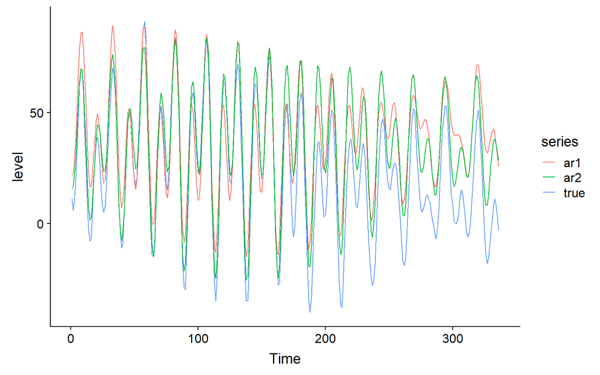

```r
y_true <- tst$level
y_pred1 <- forecast(mod1_ar, h = 336, xreg = xreg[4249:nrow(xreg),])$mean
y_pred2 <- forecast(mod2_ar, h = 336, xreg = xreg_arm[4249:nrow(xreg_arm),])$mean*100
autoplot(ts(y_true), series = "true") + autolayer(ts(y_pred1), series = "ar1") + autolayer(ts(y_pred2), series ="ar2")+labs(y = "level")
```

Confrontiamo numericamente

```r
mape1 <- round(c(MAPE(y_pred1[1], y_true[1]+0.1),MAPE(y_pred1[1:23], y_true[1:23]+0.1),MAPE(y_pred1[1:167], y_true[1:167]+0.1)),2)
mape2 <- round(c(MAPE(y_pred2[1], y_true[1]+0.1), MAPE(y_pred2[1:23], y_true[1:23]+0.1), MAPE(y_pred2[1:167], y_true[1:167]+0.1)),2)

step1_1 <- MAPE(y_pred1[1], y_true[1]+0.1)
step24_1 <- MAPE(y_pred1[1:23], y_true[1:23]+0.1)
step168_1 <- MAPE(y_pred1[1:167], y_true[1:167]+0.1)

step1_2 <- MAPE(y_pred2[1:167], y_true[1:167]+0.1)
step24_2 <- MAPE(y_pred2[1:167], y_true[1:167]+0.1)
step168_2 <- MAPE(y_pred2[1:167], y_true[1:167]+0.1)

kable_styling(kable(matrix(c(mape1, mape2), ncol = 3, nrow = 2, byrow = T, dimnames = list(c("ARIMA 1", "ARIMA 2"), c("1-step", "24-steps", "168-steps"))), caption = "One-shot performances"))
```

One-shot performances

|  | 1-step | 24-steps | 168-steps |
| --- | --- | --- | --- |
| ARIMA 1 | 0.94 | 1.72 | 0.72 |
| ARIMA 2 | 0.41 | 0.69 | 0.36 |

la tabella conferma quanto appariva intuibile attraverso il plot. Per le valutazioni one-shot, infatti, il modello ARIMA 2 raggiunge performances di errore migliori rispetto a quelle del modello ARIMA 1.

Produciamo la misurazione delle performances in rolling

```r
##ARIMA1
y <- rbind(trn, tst)
y <- y$level

# 1 step ahead predictions
score <- numeric(168)
for (i in 1:168){
  mod_prod <- Arima(y[i:(4247+i)], xreg = xreg[i:(4247+i),,drop=F], model = mod1_ar)
  pred <- forecast(mod_prod, xreg = xreg[(4248+i):(4248+i),,drop=FALSE], h = 1)$mean
  score[i] <- MAPE(pred, y[(4248 + i):(4248 + i)]+0.1)
}
pred_1step1 <- mean(score)

# 24 step ahead predictions
score <- numeric(168)
for (i in 1:168){
  mod_prod <- Arima(y[i:(4247+i)], xreg = xreg[i:(4247+i),,drop=F], model = mod1_ar)
  pred <- forecast(mod_prod, xreg = xreg[(4248+i):(4248+i+23),,drop=FALSE], h = 24)$mean
  score[i] <- MAPE(pred, y[(4248 + i):(4248 + i + 23)]+0.1)
}
pred_24step1 <- mean(score)

# 168 steps ahead predictions
score <- numeric(168)
for (i in 1:168){
  mod_prod <- Arima(y[i:(4247+i)], xreg = xreg[i:(4247+i),,drop=F], model = mod1_ar)
  pred <- forecast(mod_prod, xreg = xreg[(4248+i):(4248+i+167),,drop=FALSE], h = 168)$mean
  score[i] <- MAPE(pred, y[(4248 + i):(4248 + i + 167)]+0.1)
}
pred_168step1 <- mean(score)

##ARIMA2
y <- rbind(trn, tst)
y <- y$level/100

# 1 step ahead predictions
score <- numeric(168)
for (i in 1:168){
  mod_prod <- Arima(y[i:(4247+i)], xreg = xreg_arm[i:(4247+i),,drop=F], model = mod2_ar)
  pred <- forecast(mod_prod, xreg = xreg_arm[(4248+i):(4248+i),,drop=FALSE], h = 1)$mean
  score[i] <- MAPE(pred, y[(4248 + i):(4248 + i)]+0.001)
}
pred_1step2 <- mean(score, na.rm = T)

# 24 step ahead predictions
score <- numeric(168)
for (i in 1:168){
  mod_prod <- Arima(y[i:(4247+i)], xreg = xreg_arm[i:(4247+i),,drop=F], model = mod2_ar)
  pred <- forecast(mod_prod, xreg = xreg_arm[(4248+i):(4248+i+23),,drop=FALSE], h = 24)$mean
  score[i] <- MAPE(pred, y[(4248 + i):(4248 + i + 23)]+0.001)
}
pred_24step2 <- mean(score)

# 168 steps ahead predictions
score <- numeric(168)
for (i in 1:168){
  mod_prod <- Arima(y[i:(4247+i)], xreg = xreg_arm[i:(4247+i),,drop=F], model = mod2_ar)
  pred <- forecast(mod_prod, xreg = xreg_arm[(4248+i):(4248+i+167),,drop=FALSE], h = 168)$mean
  score[i] <- MAPE(pred, y[(4248 + i):(4248 + i + 167)]+0.001)
}
pred_168step2 <- mean(score)
```

e realizziamo una tabella riassuntiva come fatto in precedenza

```r
kable_styling(kable(matrix(c(pred_1step1, pred_24step1, pred_168step1,
         pred_1step2, pred_24step2, pred_168step2), nrow = 2, ncol = 3, byrow = T,
       dimnames = list(c("ARIMA 1 MAPE", "ARIMA 2 MAPE"), c("1-step", "24-steps", "168-steps"))), caption = "Rolling performances"))
```

Rolling performances

|  | 1-step | 24-steps | 168-steps |
| --- | --- | --- | --- |
| ARIMA 1 MAPE | 0.1175233 | 0.6666756 | 2.895241 |
| ARIMA 2 MAPE | 0.0965143 | 0.5175493 | 2.456879 |

anche in questo caso il modello ARIMA 2 sembrerebbe lavorare meglio rispetto al modello ARIMA 1.

Produciamo ancora una visualizzazione riassuntiva delle performances dei due modelli sia puntuali che in rolling

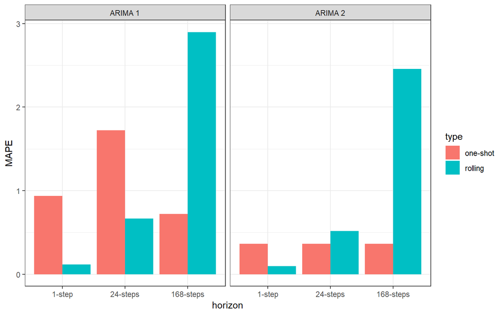

```r
perf <- data.frame(
  MAPE = c(step1_1, step24_1, step168_1, step1_2, step24_2, step168_2, pred_1step1, pred_24step1, pred_168step1,
           pred_1step2, pred_24step2, pred_168step2),
  type = c("one-shot","one-shot","one-shot","one-shot","one-shot","one-shot","rolling","rolling","rolling","rolling","rolling","rolling"),
  horizon = c("1-step", "24-steps", "168-steps", "1-step", "24-steps", "168-steps","1-step", "24-steps", "168-steps","1-step", "24-steps", "168-steps"),
  model = c("ARIMA 1","ARIMA 1","ARIMA 1","ARIMA 2","ARIMA 2","ARIMA 2","ARIMA 1","ARIMA 1","ARIMA 1","ARIMA 2","ARIMA 2","ARIMA 2"))
perf$horizon <- ordered(perf$horizon, levels = c("1-step", "24-steps", "168-steps"))
ggplot(data = perf, aes(fill = type, y = MAPE, x = horizon))+geom_bar(position = "dodge", stat = "identity")+theme_bw()+facet_wrap(~model)
```

come prevedibile, quindi, il modello basato sulle 8 armoniche estratte grazie all’utilizzo del pacchetto *oce* ottiene prestazioni generalmente migliori, sia per quanto riguarda le valutazioni one-shot che per quelle in rolling per previsioni con orizzonte ad 1 ora, a 24 ore e a 168 ore (1 settimana).

Dario Bertazioli, Fabrizio D’Intinosante

2020-01-26